# Use of K-means and SVM in ML for Detection of Genetic Association with Risk in Cases of AML

Ronald W Buie

# Background

Acute Myeloid Leukemia is a cancer affecting blood stem cells. Onset is sudden and affected cells can outcompete normal cells, resulted in complications and death. AML has multiple variants. Unlike staging used in many cancers AML affected cells are typed as part of treatment. These types serve to identify phenotypes of expression of the disease. Treatment is similar to other cancerns, involving radiation and chemotherapy. Relapse affects 50% of cases.

# Data

## Aim #1 (depreciated)

Identfiy relationships between categories of AML and genetic assay results.

### Analysis

Our analysis took two phases, grouping of cellular classifications into phenotypes, and identification of differences in genetic assay results between phenotypes.

#### Assumptions

[output not shown]

### Identifying Phenotypes Using Unsupervised Learning: K-means

Data from all 993 patients were used to identify phenotypes. Patients had a variety of tests for cell mutation typing, including positive and negatives. However, all patients also had NA values across some tests. This aligns with clinical practice where a provider focuses on testing for certain types and, once an optimal course of treatment is identified, has no need to further specify the types of mutation. Because a step of clinical expertise was involved, we decided to identify all NA values has 0 (not found), under the assumption that, more likely than not, something not tested for was not expected by the expert.

[output not shown]

### Testing ASsociation of Outcome and Phenotype groups

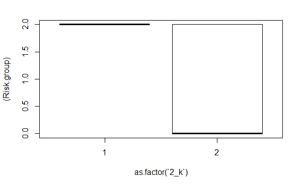

```
Call:
glm(formula = as.factor(Risk.group) ~ as.factor(`2_k`), family = "binomial",
    data = GeneWKM)

Deviance Residuals:
     Min        1Q    Median        3Q       Max
-1.13301  -1.13301   0.00013   1.22247   1.22247

Coefficients:
                  Estimate Std. Error z value Pr(>|z|)
(Intercept)          18.57    1360.06   0.014    0.989
as.factor(`2_k`)2   -18.67    1360.06  -0.014    0.989

(Dispersion parameter for binomial family taken to be 1)

    Null deviance: 187.81  on 136  degrees of freedom
Residual deviance: 157.72  on 135  degrees of freedom
AIC: 161.72

Number of Fisher Scoring iterations: 17

as.factor(`2_k`)2
        -18.67143
```

[output not shown]

logistic regression was used to test a relationship between Risk group and phenotype group. While a large difference was identified between groups, the result was highly insignificant.

## Aim 2

Identify genes with strong associations between patient risk category and genetic eassay results using SVM

### Assumptions

Our data included a variable for risk of condition (relapse?). This variable included some unknowns and 3 levels. In order to increase dichotomy, those of high or normal risk were assigned an indicator of 1, and low risk an indicator of 0.

### Analysis

[output not shown]

## Aim 3

Testing performance of QDA on survival and genetic data.